# Children Asthma Healthcare Utilization 2017

Jumoke Ajakaiye

5/18/2021

# Introduction

Allegheny County (Pennsylvania) and the City of Pittsburgh both publish their data through the Western Pennsylvania Regional Data Center. In addition, the Western Pennsylvania Regional Data Center supports key community initiatives by making public information easier to find and use.

The Data Center maintains Allegheny County and the City of Pittsburgh’s open data portal and provides several services to data publishers and users. The Data Center also hosts datasets from these public sector agencies, academic institutions, and non-profit organizations. The University of Pittsburgh’s Center for Social and Urban Research manages the Data Center and collaborates with the University, Allegheny County, and Pittsburgh’s City.

**Metadata Updated: November 30, 2020**

This data shows healthcare utilization for asthma by Allegheny County and City of Pittsburg residents. It counts asthma-related visits to the Emergency Department (ED), hospitalizations, urgent care visits, and asthma controller medication dispensing events.

The asthma data was compiled as part of the Allegheny County Health Department’s Asthma Task Force, established in 2018. The Task Force was formed to identify strategies to decrease asthma inpatient and emergency utilization among children (ages 0-18), focusing on children receiving services funded by Medicaid. With the increase of asthma-related usage in Allegheny County, the data is being used to understand and gather data to improve and inform the task force’s recommended actions. In addition, this data will also be used to evaluate progress toward reducing asthma-related hospitalization and ED visits. The Allegheny County Health Department’s Asthma Task Force criteria of asthma utilization are:

- **at least 1 ED visit (dx 1-10 J45.xxx)**
- **at least 1 acute inpatient encounter (dx 1-10 J45.xxx)**
- **at least 1 outpatient visit or observational stay (dx 1-10 J45.xxx)**
- **at least 1 asthma controller medication dispensing event**

Regarding this data, we defined asthma using the International Classification of Diseases, Tenth Revision (IDC-10) classification system code J45.xxx [here](https://icd.who.int/browse10/2016/en#/J40-J47). The ICD-10 system classifies diagnoses, symptoms, and procedures in the U.S. healthcare system.

Children seeking care for an asthma-related claim in 2017 are represented in the data. The Health Department compiles data from medical claims submitted to three health plans (UPMC, Gateway Health, and Highmark). Claims may also come from people enrolled in Medicaid plans managed by these insurers. The Health Department estimates that 74% of the County’s population aged 0-18 is represented in the data.

# The Data Center Objective

The objective is to decrease asthma inpatient and emergency utilization among children (ages 0-18) and evaluate progress toward reducing asthma-related hospitalization and Emergency department visits.

**Notes:** In this analysis, I collected one dataset to analyze and gain insight into Asthma utilization rates in children.

## Setting up my environment

**Notes:** I’m setting up my R environment by loading the ‘tidyverse’ packages.

```r
install.packages("tidyverse",repos = "http://cran.us.r-project.org")
library(tidyverse)
```

```r
library(ellipsis)
library(ggplot2)
library(janitor)
library(readr)
library(lubridate)
library(dplyr)
```

## Loading the Data

```r
asthma <- read.csv("casthma_2017.csv")
```

```r
asthma <- asthma %>%
  janitor::clean_names()
```

## Exploring the Dataframe Table

```r
head(asthma)
```

```
##   census_tract ed_visits ed_hosp uc_visits asthma_use total_members
## 1  42003010300         2       0         0          6            83
## 2  42003020100        32      19         3        223          2114
## 3  42003020300         0       0         0          2            48
## 4  42003030500        11       3         3         61           422
## 5  42003040200         2       1         1         18           138
## 6  42003040400         0       0         0          1            17
```

```r
colnames(asthma)
```

```
## [1] "census_tract"  "ed_visits"     "ed_hosp"       "uc_visits"
## [5] "asthma_use"    "total_members"
```

## Understanding Summary Statistics

```r
n_distinct(asthma$total_members)
```

```
## [1] 329
```

```r
nrow(asthma)
```

```
## [1] 398
```

A quick summary of statistics we’d want to know about the dataframe.

```r
asthma %>%
  select(ed_visits,
         ed_hosp,
         uc_visits,
         asthma_use) %>%
  summary()
```

```
##    ed_visits         ed_hosp         uc_visits        asthma_use
##  Min.   : 0.000   Min.   : 0.000   Min.   :0.0000   Min.   :  0.00
##  1st Qu.: 1.000   1st Qu.: 0.000   1st Qu.:0.0000   1st Qu.: 20.00
##  Median : 2.000   Median : 1.000   Median :0.0000   Median : 35.00
##  Mean   : 3.241   Mean   : 1.628   Mean   :0.6457   Mean   : 38.21
##  3rd Qu.: 4.000   3rd Qu.: 2.000   3rd Qu.:1.0000   3rd Qu.: 53.00
##  Max.   :32.000   Max.   :19.000   Max.   :6.0000   Max.   :240.00
```

# Data Analysis

From this dataframe, I’ll create another dataframe combining ed_visits and ed_hosp since uc_visits is urgent care. The business task is to decrease asthma utilization in children under 18 admitted to the Emergency Department.

```r
asthma_v2 <- asthma %>%
  select(census_tract,
         uc_visits,
         total_members,
         asthma_use,
         ed_visits,
         ed_hosp) %>%
  mutate(ed_total = ed_visits + ed_hosp)
```

Another quick summary of statistics we’d want to know about the new dataframe.

```r
asthma_v2 %>%
  select(uc_visits,
         ed_visits,
         ed_hosp,
         asthma_use,
         total_members,
         ed_total) %>%
  summary()
```

```
##    uc_visits        ed_visits         ed_hosp         asthma_use
##  Min.   :0.0000   Min.   : 0.000   Min.   : 0.000   Min.   :  0.00
##  1st Qu.:0.0000   1st Qu.: 1.000   1st Qu.: 0.000   1st Qu.: 20.00
##  Median :0.0000   Median : 2.000   Median : 1.000   Median : 35.00
##  Mean   :0.6457   Mean   : 3.241   Mean   : 1.628   Mean   : 38.21
##  3rd Qu.:1.0000   3rd Qu.: 4.000   3rd Qu.: 2.000   3rd Qu.: 53.00
##  Max.   :6.0000   Max.   :32.000   Max.   :19.000   Max.   :240.00
##  total_members       ed_total
##  Min.   :   1.0   Min.   : 0.000
##  1st Qu.: 249.5   1st Qu.: 1.000
##  Median : 412.0   Median : 3.000
##  Mean   : 466.2   Mean   : 4.869
##  3rd Qu.: 646.8   3rd Qu.: 6.000
##  Max.   :2398.0   Max.   :51.000
```

```r
head(asthma_v2)
```

```
##   census_tract uc_visits total_members asthma_use ed_visits ed_hosp ed_total
## 1  42003010300         0            83          6         2       0        2
## 2  42003020100         3          2114        223        32      19       51
## 3  42003020300         0            48          2         0       0        0
## 4  42003030500         3           422         61        11       3       14
## 5  42003040200         1           138         18         2       1        3
## 6  42003040400         0            17          1         0       0        0
```

```r
colnames(asthma_v2)
```

```
## [1] "census_tract"  "uc_visits"     "total_members" "asthma_use"
## [5] "ed_visits"     "ed_hosp"       "ed_total"
```

Total members are the number of Allegheny County, and City of Pittsburgh residents under 18 enrolled in Gateway, Highway, or UMPC health plans based on the 2010 census_tract ID.

In the Allegheny County and City of Pittsburgh, the healthcare system’s highest asthma usage administered to residents under 18 is about 250 in the Emergency Department.

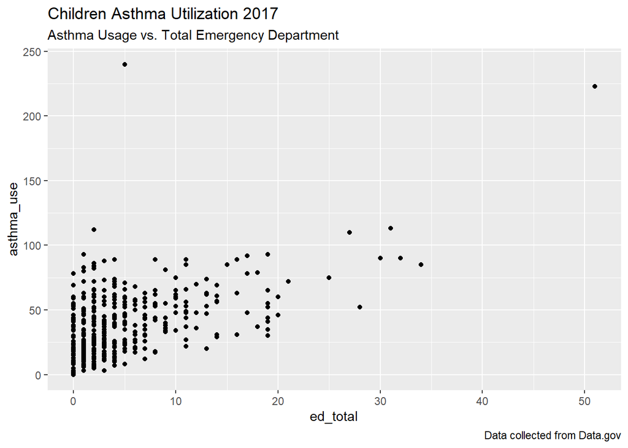

```r
ggplot(data = asthma_v2, aes(x = ed_total, y = asthma_use))+
  geom_point()+
  labs(title = "Children Asthma Utilization 2017",
       subtitle = "Asthma Usage vs. Total Emergency Department", caption = "Data collected from Data.gov")
```

There is an increase of asthma_use in total_members beginning from 0 to 1000 members.

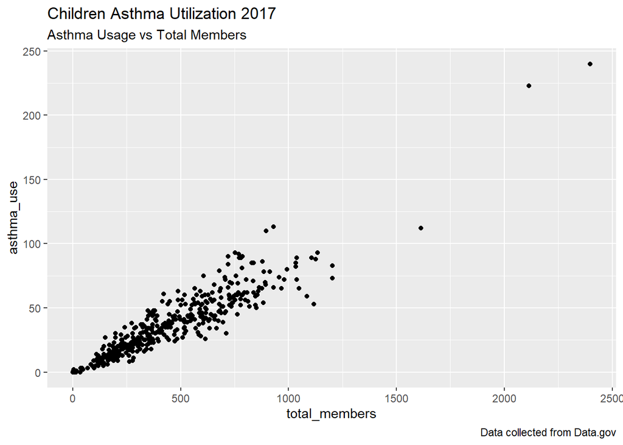

```r
ggplot(data = asthma_v2)+
  geom_point(mapping = aes(x=total_members, y=asthma_use))+ labs(title = "Children Asthma Utilization 2017",subtitle = "Asthma Usage vs Total Members", caption = "Data collected from Data.gov")
```

This visual is the asthma_use, and the average of asthma used is 38 in 2017.

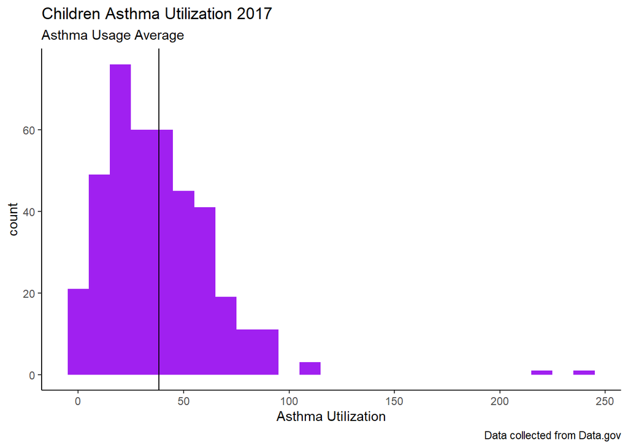

```r
ggplot(data = asthma_v2, aes (x = asthma_use))+
  geom_histogram(fill = "purple", bins = 25)+
  geom_vline(aes(xintercept=mean(asthma_use)))+
  xlab("Asthma Utilization")+theme_classic()+
  labs(title = "Children Asthma Utilization 2017", subtitle = "Asthma Usage Average", caption = "Data collected from Data.gov")
```

```r
asthma_v2 %>%
  summarise(mean(asthma_use))
```

```
##   mean(asthma_use)
## 1         38.21106
```

This visual is the ed_total, and the average is about five residents under 18 admitted in 2017.

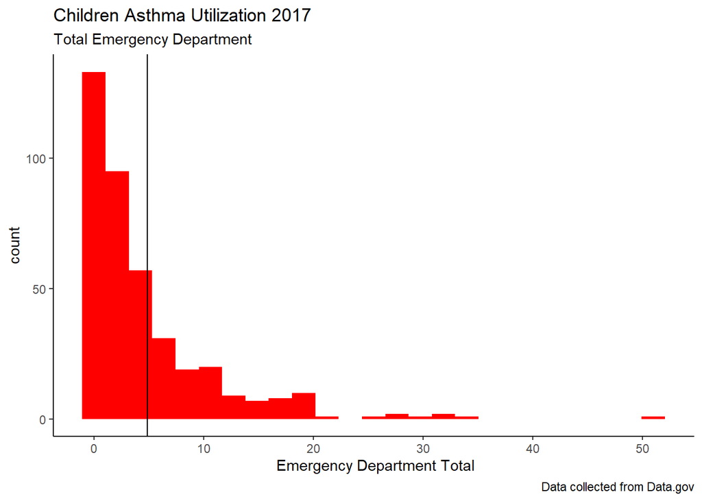

```r
ggplot(data = asthma_v2)+
  geom_histogram(mapping = aes (x = ed_total), fill = "red",
  bins = 25)+
  geom_vline(aes(xintercept=mean(ed_total)))+
  xlab(" Emergency Department Total")+ theme_classic()+
  labs(title = "Children Asthma Utilization 2017", subtitle = "Total Emergency Department", caption = "Data collected from Data.gov")
```

```r
asthma_v2 %>%
  summarise(mean(ed_total))
```

```
##   mean(ed_total)
## 1       4.869347
```

The illustration above is the ed_total, and this visual below analyzes only the ed_visits. The average of ed_visits is three residents under 18 admitted in 2017.

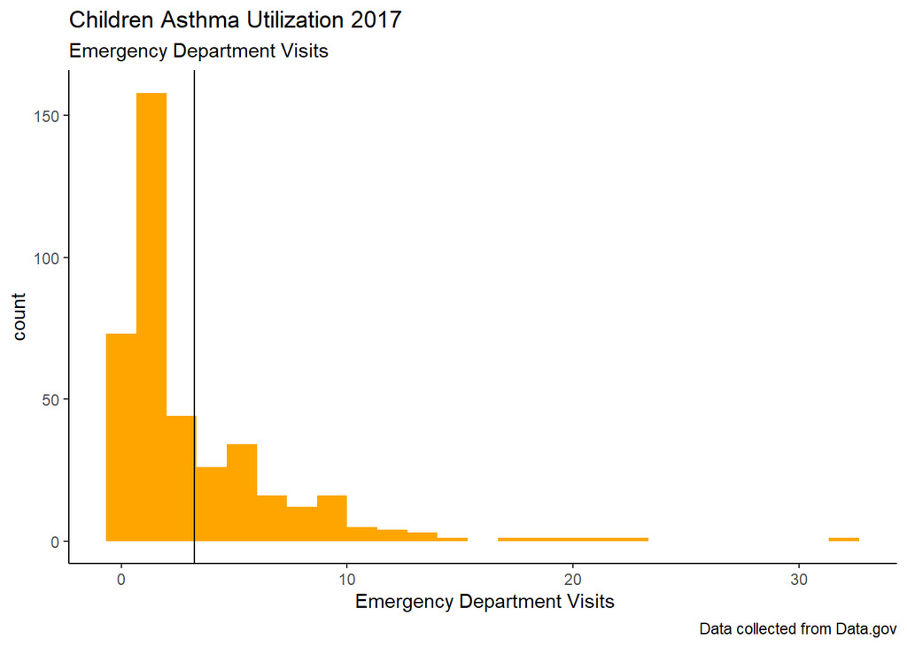

```r
ggplot(data = asthma_v2)+
  geom_histogram(mapping = aes (x = ed_visits), fill = "orange",
  bins = 25)+
  geom_vline(aes(xintercept=(mean(ed_visits))))+
  xlab(" Emergency Department Visits")+ theme_classic()+
  labs(title = "Children Asthma Utilization 2017", subtitle = "Emergency Department Visits", caption = "Data collected from Data.gov")
```

```r
asthma_v2 %>%
  summarise(mean(ed_visits))
```

```
##   mean(ed_visits)
## 1        3.241206
```

This visual is ed_hosp, and the average number of residents under 18 hospitalized is 2 in 2017.

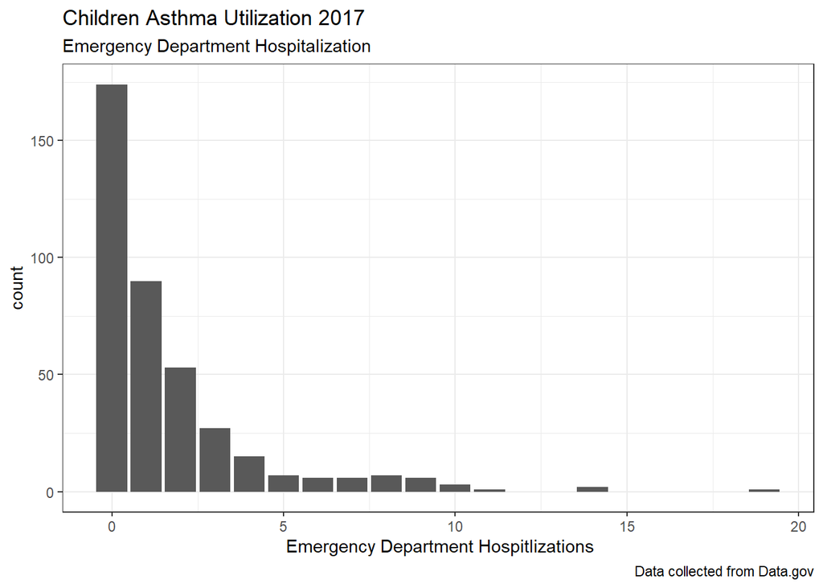

```r
ggplot(data = asthma_v2)+
  geom_bar(mapping = aes (x = ed_hosp))+
  xlab(" Emergency Department Hospitlizations")+ theme_bw()+
  labs(title ="Children Asthma Utilization 2017", subtitle = "Emergency Department Hospitalization", caption = "Data collected from Data.gov")
```

```r
asthma_v2 %>%
  summarise(mean(ed_hosp))
```

```
##   mean(ed_hosp)
## 1      1.628141
```

Ed_visits and ed_hosp show a trend of residents under 18 admitted to the Emergency Department 0 to 25 times in a year.

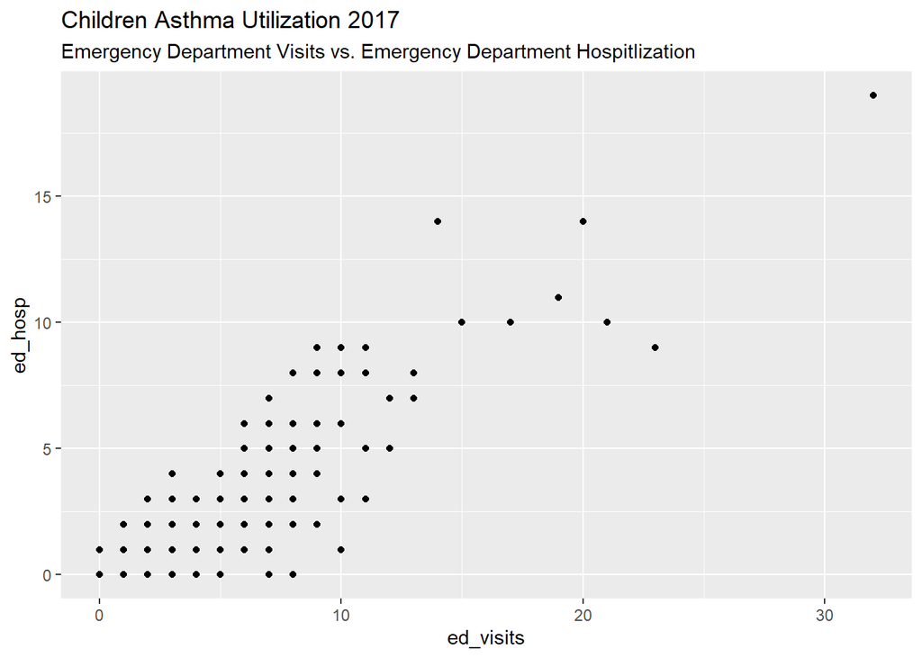

```r
ggplot(data = asthma_v2)+
  geom_point(mapping = aes(x = ed_visits, y = ed_hosp))+ labs(title = "Children Asthma Utilization 2017", subtitle = "Emergency Department Visits vs. Emergency Department Hospitlization")+theme_gray()
```

I created another dataframe to calculate the percentage of residents under 18 **(ed_total)** from **total_members** admitted in the Emergency Department.

```r
asthma_total <- asthma_v2 %>%
  select(total_members,
         asthma_use,
         ed_total) %>%
  mutate(ed_per = ed_total / total_members)
```

A quick summary of asthma_total.

```r
head(asthma_total)
```

```
##   total_members asthma_use ed_total     ed_per
## 1            83          6        2 0.02409639
## 2          2114        223       51 0.02412488
## 3            48          2        0 0.00000000
## 4           422         61       14 0.03317536
## 5           138         18        3 0.02173913
## 6            17          1        0 0.00000000
```

```r
asthma_total %>%
  select(ed_per) %>%
  summary()
```

```
##      ed_per
##  Min.   :0.000000
##  1st Qu.:0.002288
##  Median :0.006713
##  Mean   :0.011408
##  3rd Qu.:0.017060
##  Max.   :0.073333
```

The percentage of residents under 18 is higher between 0% to 2% admitted to the Emergency Department in 2017.

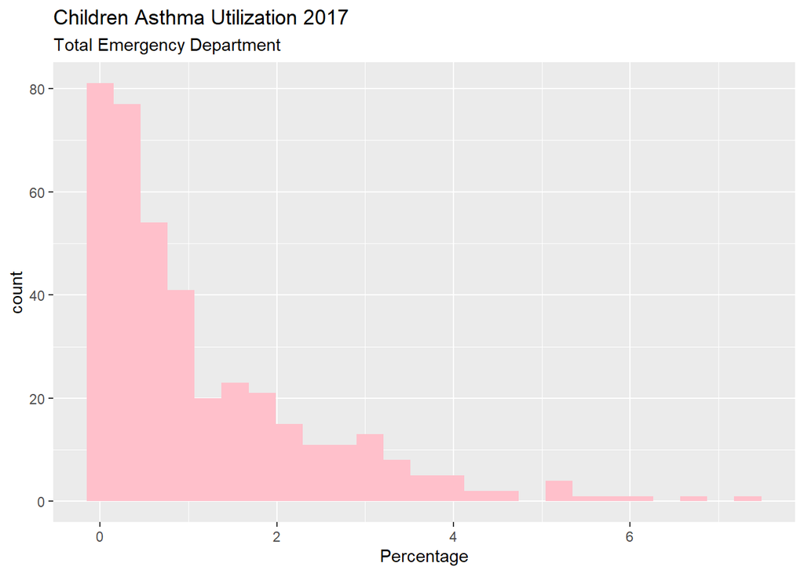

```r
ggplot(data=asthma_total)+
  geom_histogram(mapping = aes(x=ed_per *100), bins = 25, fill = "pink")+
  labs(title = "Children Asthma Utilization 2017", subtitle = "Total Emergency Department")+
  xlab("Percentage")
```

# Summary of my analysis

The Data Center’s objective is to reduce children 18 years and younger from being admitted to the Emergency Department and asthma utilization usage in Allegheny County and the City of Pittsburgh.

I would recommend the Data Center to create an ID for the residents under 18 in gauging if the same residents are visiting or hospitalized multiple times in the year. Unfortunately, there’s not enough data to analyze if residents are counted once or numerous times based on the Health Department’s Asthma Task Force criteria.

**I’m open to receiving feedback on my analysis. Thank you.**

# Resources

For more information, check out this link to review the dataset of Children Asthma Healthcare Utilization [here](https://catalog.data.gov/dataset/childhood-asthma-healthcare-utilization) and for more resources see Data.Gov Organizations Dataset Catalog [here](https://catalog.data.gov/organization/about/allegheny-county-city-of-pittsburgh-western-pa-regional-data-center).